# W3cubDocs

#### Notes

For an example, see examples/linear_model/plot_lasso_coordinate_descent_path.py.

**`predict(X)` [[source]](https://github.com/scikit-learn/scikit-learn/blob/bac89c2/sklearn/linear_model/base.py#L200)**

Predict using the linear model

| Parameters: | **`X : array_like or sparse matrix, shape (n_samples, n_features)`** Samples. |
| --- | --- |
| Returns: | **`C : array, shape (n_samples,)`** Returns predicted values. |

**`score(X, y, sample_weight=None)` [[source]](https://github.com/scikit-learn/scikit-learn/blob/bac89c2/sklearn/base.py#L296)**

Returns the coefficient of determination R^2 of the prediction.

The coefficient R^2 is defined as (1 - u/v), where u is the residual sum of squares ((y_true - y_pred) ** 2).sum() and v is the total sum of squares ((y_true - y_true.mean()) ** 2).sum(). The best possible score is 1.0 and it can be negative (because the model can be arbitrarily worse). A constant model that always predicts the expected value of y, disregarding the input features, would get a R^2 score of 0.0.

[output not shown]

**`set_params(**params)` [[source]](https://github.com/scikit-learn/scikit-learn/blob/bac89c2/sklearn/base.py#L189)**

Set the parameters of this estimator.

The method works on simple estimators as well as on nested objects (such as pipelines). The latter have parameters of the form `<component>__<parameter>` so that it’s possible to update each component of a nested object.

| Returns: | **self** |
| --- | --- |

**`sparse_coef_`**

sparse representation of the fitted `coef_`

## Examples using `sklearn.linear_model.Lasso`

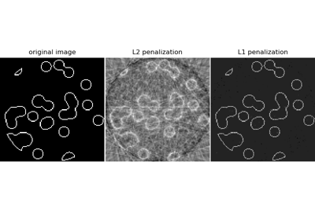

Compressive sensing: tomography reconstruction with L1 prior (Lasso)

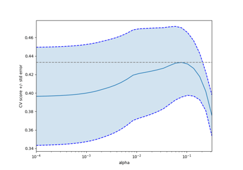

Cross-validation on diabetes Dataset Exercise

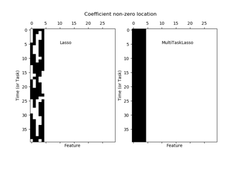

Joint feature selection with multi-task Lasso

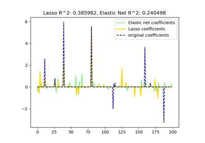

Lasso and Elastic Net for Sparse Signals

© 2007–2018 The scikit-learn developers  
Licensed under the 3-clause BSD License.  
http://scikit-learn.org/stable/modules/generated/sklearn.linear_model.Lasso.html